# R Notebook

#### Summary of the model

|  | var | rel.inf |
| --- | --- | --- |
| atemp | atemp | 10.3187478 |
| hum | hum | 9.4385700 |
| hr17 | hr17 | 8.9445062 |
| temp | temp | 8.5430272 |
| hr18 | hr18 | 7.3776047 |
| yr1 | yr1 | 6.4296424 |
| hr8 | hr8 | 6.3174156 |
| weekday6 | weekday6 | 4.3539774 |
| hr19 | hr19 | 2.3681992 |
| hr3 | hr3 | 2.2190412 |

[output cut: 42 more lines]

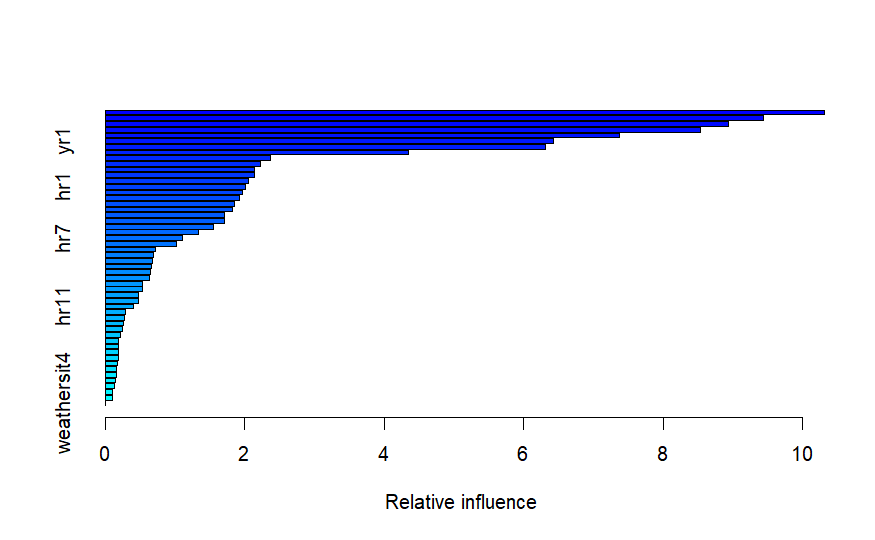

```r
summary(boost.model)
```

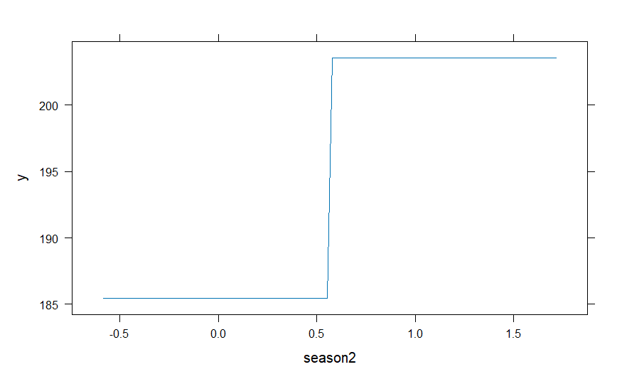

```r
plot(boost.model)
```

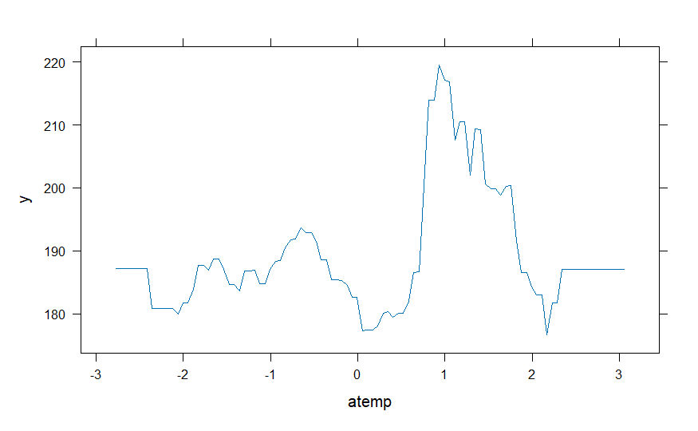

```r
plot(boost.model,i="atemp")
```

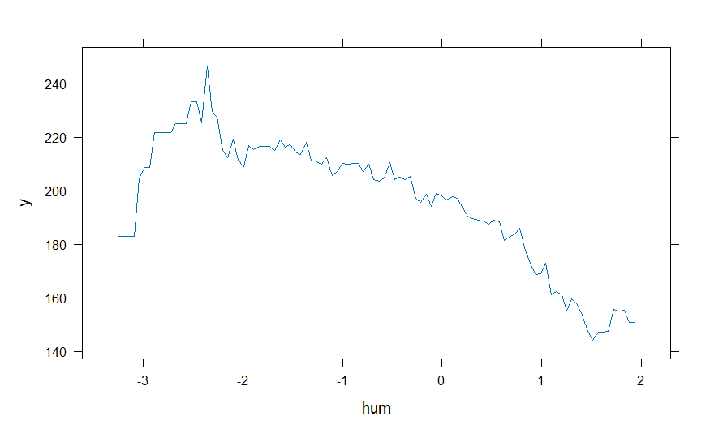

```r
plot(boost.model,i="hum")
```

#### Evalution metrics

```r
yhat.boost=predict(boost.model,newdata=dff[-trainIndex,],n.trees=5000)
mse_gbm <- mean((yhat.boost-dff$cnt[-trainIndex])^2)
mae_gbm <- mean(abs(yhat.boost-dff$cnt[-trainIndex]))
rmse_gbm <- sqrt(mse_gbm)
r_squared_gbm = 1 - sum((yhat.boost-dff$cnt[-trainIndex])^2) / sum((dff$cnt[-trainIndex] - mean(dff$cnt[-trainIndex]))^2)
```

#### Plotting the Actual values Vs Predicted vaues

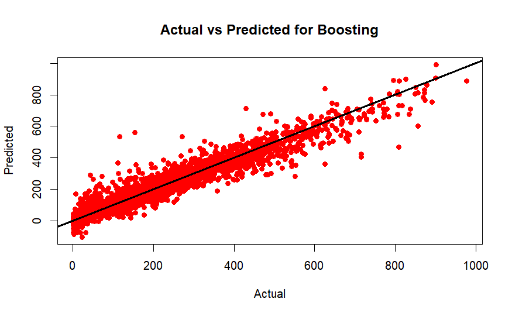

```r
plot(dff$cnt[-trainIndex], yhat.boost, pch = 16, col = "red", main = "Actual vs Predicted for Boosting", xlab = "Actual", ylab = "Predicted")
abline(a = 0, b = 01, col = "black",lty=1,lwd=3)
```

#### Evaluation Metrics

```r
# Display the results
cat("R-squared: ", r_squared_gbm, "\n")
```

```
R-squared:  0.9289999
```

```r
cat("Mean Square Error (MSE): ", mse_gbm, "\n")
```

```
Mean Square Error (MSE):  2275.473
```

```r
cat("Mean Absolute Error (MAE): ", mae_gbm, "\n")
```

```
Mean Absolute Error (MAE):  31.73732
```

```r
cat("Root Mean Square Error (RMSE): ", rmse_gbm, "\n")
```

```
Root Mean Square Error (RMSE):  47.70192
```

## Neural Network

Scaled the all independent variables as X and dependent variables as y

```r
####  Neural Network

X <- scale(model.matrix(cnt~. -1, data=df0))
y <- df0$cnt
```

Split tbe data into training and testing

```r
x_train <- X[trainIndex, ]
y_train <- y[trainIndex]
x_test <- X[-trainIndex, ]
y_test <- y[-trainIndex]
```

Implement the model with learbibg rate= 0.001

```r
# Assuming you want to use L2 regularization with lambda = 0.001
l2_lambda <- 0.001

# Build a neural network model
model <- keras_model_sequential() %>%
  layer_dense(units = 128, activation = 'relu', input_shape = ncol(X), kernel_regularizer = regularizer_l2(l2_lambda)) %>%
  layer_dropout(rate = 0.2) %>%
  layer_dense(units = 64, activation = 'relu', kernel_regularizer = regularizer_l2(l2_lambda)) %>%
  layer_dropout(rate = 0.2) %>%
  layer_dense(units = 32, activation = 'relu', kernel_regularizer = regularizer_l2(l2_lambda)) %>%
  layer_dropout(rate = 0.2) %>%
  layer_dense(units = 1)
```

```
2023-12-30 01:58:13.726795: I tensorflow/core/platform/cpu_feature_guard.cc:182] This TensorFlow binary is optimized to use available CPU instructions in performance-critical operations.
To enable the following instructions: SSE SSE2 SSE3 SSE4.1 SSE4.2 AVX AVX2 AVX_VNNI FMA, in other operations, rebuild TensorFlow with the appropriate compiler flags.
```

Compile the model with adam optimizer and loss are MSE

```r
# Compile the model
model %>% compile(
  optimizer = 'adam',
  loss = 'mean_squared_error'  # For regression tasks
)
```

Fitting the model with 80% for training and 20 % for validation of Training data. i.e., 64% for full data is used for training and 16% used for validation

```r
# Train the model
model %>% fit(
  x_train,y_train,
  epochs = 20,
  batch_size = 32,
  validation_split = 0.2
)
```

#### Prediction the testing data valuesS

```r
npred <- predict(model , x_test)
```

#### Plotting the Actual values Vs Predicted vaues

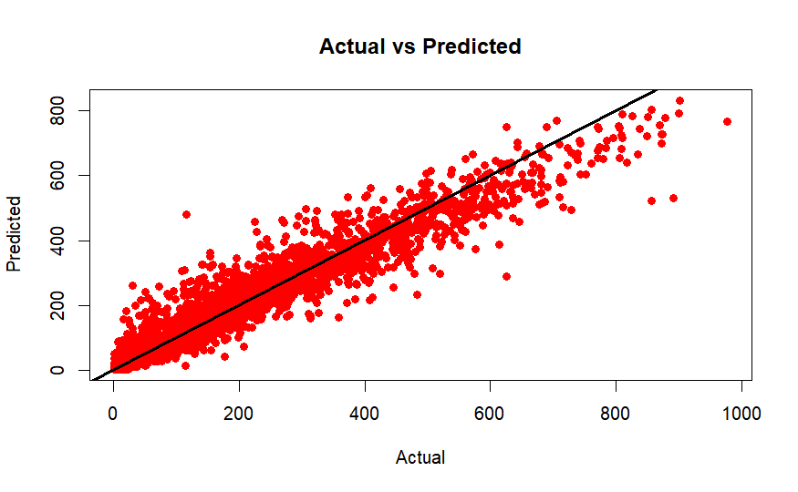

```r
plot(y_test, npred, pch = 16, col = "red", main = "Actual vs Predicted", xlab = "Actual", ylab = "Predicted")
abline(a = 0, b = 1, col = "black",lty=1,lwd=3)
```

#### Evaluation Metrics

```r
mse_nn <- mean((npred-y_test)^2)
mae_nn <- mean(abs(npred-y_test))
rmse_nn <- sqrt(mse_nn)
r_squared_nn <-  1 - sum((npred-y_test)^2) / sum((y_test - mean(y_test))^2)
# Display the results
cat("R-squared: ", r_squared_nn, "\n")
```

```
R-squared:  0.9231061
```

```r
cat("Mean Square Error (MsE): ", mse_nn, "\n")
```

```
Mean Square Error (MsE):  2464.363
```

```r
cat("Mean Absolute Error (MAE): ", mae_nn, "\n")
```

```
Mean Absolute Error (MAE):  31.85471
```

```r
cat("Root Mean Square Error (RMSE): ", rmse_nn, "\n")
```

```
Root Mean Square Error (RMSE):  49.64236
```

# Evaluation Metrics

```r
# Create a sample data frame (replace this with your actual data)
model_data <- data.frame(
  Model = c("linear Regression","poly 2","poly 3","poly 4","LR_InterTerms","forward","backward","lasso","ridge","random forest","boosting","NN"),
  RSquare = c(r_squared_lm,r_squared_lm2,r_squared_lm3,r_squared_lm4,r_squared_it,r_squared_fw,r_squared_bw,r_squared_lr,r_squared_rr,r_squared_rf,r_squared_gbm,r_squared_nn)*100,
  MAE = c(mae_lm,mae_lm2,mae_lm3,mae_lm4,mae_it,mae_fw,mae_bw,mae_lr,mae_rr,mae_rf,mae_gbm,mae_nn),
  RMSE = c(rmse_lm,rmse_lm2,rmse_lm3,rmse_lm4,rmse_it,rmse_fw,rmse_bw,rmse_lr,rmse_rr,rmse_rf,rmse_gbm,rmse_nn)
)

# Melt the data frame for easy plotting

melted_data <- melt(model_data, id.vars = "Model")
#melted_data$variable <- melted_data$variable * 100

melted_data$Model <- reorder(melted_data$Model, melted_data$value, FUN = function(x) min(x))

# Function to generate a color palette
get_color_palette <- function(n) {
  hcl(h = seq(15, 375, length.out = n + 1), l = 65, c = 100)[1:n]
}
```

### Mean Absolute Error

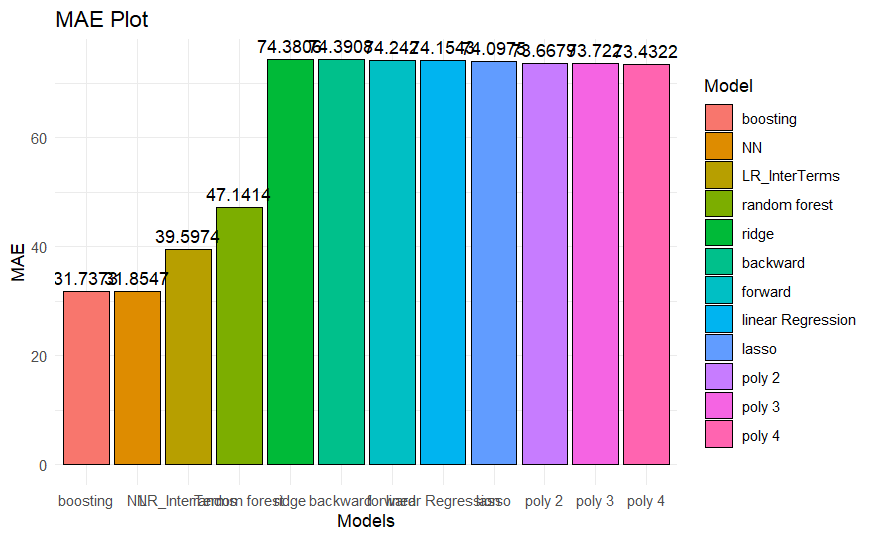

```r
# Separate plots for MSE, RMSE, and RSquare with different colors and labels
mae_plot <- ggplot(subset(melted_data, variable == "MAE"), aes(x = Model, y = value, fill = Model)) +
  geom_bar(stat = "identity", color = "black") +
  scale_fill_manual(values = get_color_palette(nrow(model_data))) +
  geom_text(aes(label = round(value,4)), vjust = -0.5) +
  labs(title = "MAE Plot",
       x = "Models",
       y = "MAE") +
  theme_minimal()

# Print the plots
print(mae_plot)
```

### Root Mean Square Error

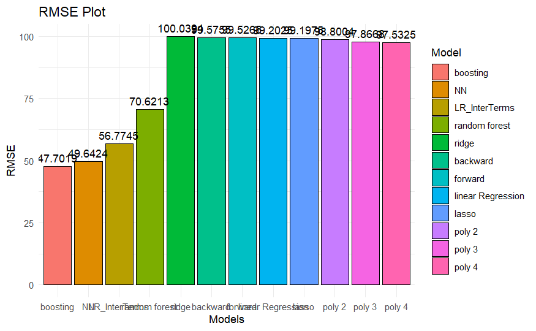

```r
rmse_plot <- ggplot(subset(melted_data, variable == "RMSE"), aes(x = Model, y = value, fill = Model)) +
  geom_bar(stat = "identity", color = "black") +
  scale_fill_manual(values = get_color_palette(nrow(model_data))) +
  geom_text(aes(label = round(value,4)), vjust = -0.5) +
  labs(title = "RMSE Plot",
       x = "Models",
       y = "RMSE") +
  theme_minimal()
print(rmse_plot)
```

### R squared

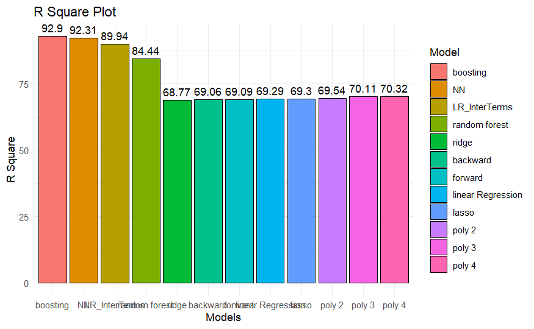

```r
rsquare_plot <- ggplot(subset(melted_data, variable == "RSquare"), aes(x = Model, y = value, fill = Model)) +
  geom_bar(stat = "identity", color = "black") +
  scale_fill_manual(values = get_color_palette(nrow(model_data))) +
  geom_text(aes(label = round(value, 2)), vjust = -0.5) +
  labs(title = "R Square Plot",
       x = "Models",
       y = "R Square") +
  theme_minimal()


print(rsquare_plot)
```

### Display all model values with all Evalutoion metrics

```r
model_data
```

| Model | RSquare | MAE | RMSE |
| --- | --- | --- | --- |
| linear Regression | 69.29337 | 74.15430 | 99.20247 |
| poly 2 | 69.54175 | 73.66787 | 98.80045 |
| poly 3 | 70.11467 | 73.72196 | 97.86680 |
| poly 4 | 70.31851 | 73.43218 | 97.53249 |
| LR_InterTerms | 89.94243 | 39.59739 | 56.77445 |
| forward | 69.09245 | 74.24202 | 99.52650 |
| backward | 69.06202 | 74.39076 | 99.57548 |
| lasso | 69.29642 | 74.09753 | 99.19755 |
| ridge | 68.77307 | 74.38064 | 100.03939 |
| random forest | 84.43822 | 47.14141 | 70.62135 |

[output cut: 2 more lines]

```r
NA
```